$$\mathbf{\text{Universidade Federal do Paraná}}$$

$$\mathbf{\text{CE063C - Sensometria}}$$

$$\mathbf{\text{Análise Quantitativa Descritiva (ADQ)}}$$

$$\mathbf{\text{Avaliação de Marcas de Wafer Sabor Chocolate}}$$

# 1 ADQ

Métodos sensoriais descritivos são muito utilizados na indústria de alimentos quando se tem interesse em verificar a qualidade sensorial de um produto.

Dentre as técnicas disponíveis está a chamada **Análise Descritiva Quantitativa (ADQ)**. Trata-se de um método que visa identificar e quantificar os atributos sensoriais de alimentos.

> A Análise Descritiva Quantitativa (ADQ) é a técnica de descrição sensorial mais utilizada na área de alimentos, pois permite o levantamento, a descrição e a quantificação dos atributos sensoriais detectáveis no produto, utilizando julgadores com alto grau de treinamento e análise estatística dos dados (STONE e SIDEL, 2004).

Pode-se citar como possíveis aplicações do ADQ:

- Acompanhamento de produtos concorrentes
- Testes de armazenamento para verificar possíveis alterações no decorrer do tempo
- Desenvolvimento de novos produtos
- Controle da qualidade de alimentos
- Determinações químicas versus respostas sensoriais

As etapas para realização da ADQ são:

1. Pré-seleção dos julgadores,
2. Levantamento dos atributos,
3. Definições e referências dos atributos selecionados,
4. Seleção final dos julgadores,
5. Avaliação das amostras,
6. Análise dos dados.

# 2 O Experimento

# 3 Brainstorming

A equipe de julgadores para a Análise Descritiva Quantitativa do experimento foi composta pelos alunos da disciplina optativa CE063C - Sensometria na Universidade Federal do Paraná (UFPR).

Considerando as etapas citadas sessão **ADQ** para realização de uma Análise Descritiva Quantitativa, os passos 2 (levantamento dos atributos) e 3 (definições e referências dos atributos selecionados) foram chamados de ‘brainstorming’.

Nesta etapa todos os 9 avaliadores provaram os produtos das diferentes marcas a fim de elencar atributos possíveis de serem avaliados por todo o grupo. Foram listadas características relacionadas à aparência, aroma e sabor.

Após todos os avaliadores provarem os produtos e elencarem, individualmente, características viáveis de avaliação, foi eleito um mediador para unificar as provas individuais em um único conjunto de atributos que realmente descrevessem os atributos das amostras.

Por fim, com os atributos selecionados, os avaliadores definiram as referências para construção da escala (uma referência de mínimo e uma de máximo). E, com a escala definida, foi realizado o treinamento dos avaliadores com as devidas escalas.

# 4 Escala e Atributos

Com os atributos escolhidos e referências definidas, foram montadas as fichas de avaliação, com escalas não estruturadas de 9 centímetros, ancoradas nos pontos extremos definidos como referência: à esquerda pela referência que representava ausência ou mínimo do atributo e à direita pelo máximo ou presença do atributo.

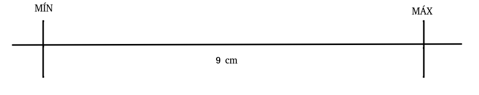

Exemplo de escala não estruturada de 9 cm.

Os atributos e referências selecionadas foram:

|  | Atributo | Definição | Mínimo | Máximo |
| --- | --- | --- | --- | --- |
| 1 | Cor recheio | Cor marrom escuro | caramelo | Chocolate Amargo |
| 2 | Cheiro | Cheiro parecido com chocolate | Margarina | Achocolatado |
| 3 | Crocância | Nível de crocância | Marshmallow | Ruffles |
| 4 | Sabor |  | Gordura | Chocolate ao leite |
| 5 | Doçura | Sensação provocada quando ingerimos açucar | Imperceptível | Açucar puro |
| 6 | Nível de gordura | Sensação pastosa deixada na boca | Imperceptível | Margarina |
| 7 | Quantidade de recheio | Presença de recheio aparente | Imperceptível | Três camadas |

Os provadores selecionados participaram dos testes, onde as amostras foram servidas em bandejas padronizadas, com as amostras codificadas e balanceadas, juntamente com a ficha de avaliação com os atributos definidos na etapa de brainstorming e repetiu-se o procedimento 3 vezes por julgador.

# 5 Dados

Os dados foram coletados com os alunos da turma de Sensometria. Os alunos foram treinados e depois submetidos aos testes. Cada um executou o teste 3 vezes em 2 dias diferentes (Duas vezes 20/09 e a última 25/09). Depois de terminar os experimentos todos os resultados foram passados para o computador para começar as analises.

# 6 Análise estatística

## 6.1 Importação de dados

Os dados foram importados para o software da seguinte forma:

```r
dados <- read.csv2('data.csv', sep = ',', dec = '.', header = T)
```

## 6.2 Análise Exploratória

A fim de explorar os resultados graficamente, foram feitos gráficos com avaliadores x atributo e marca x atributo:

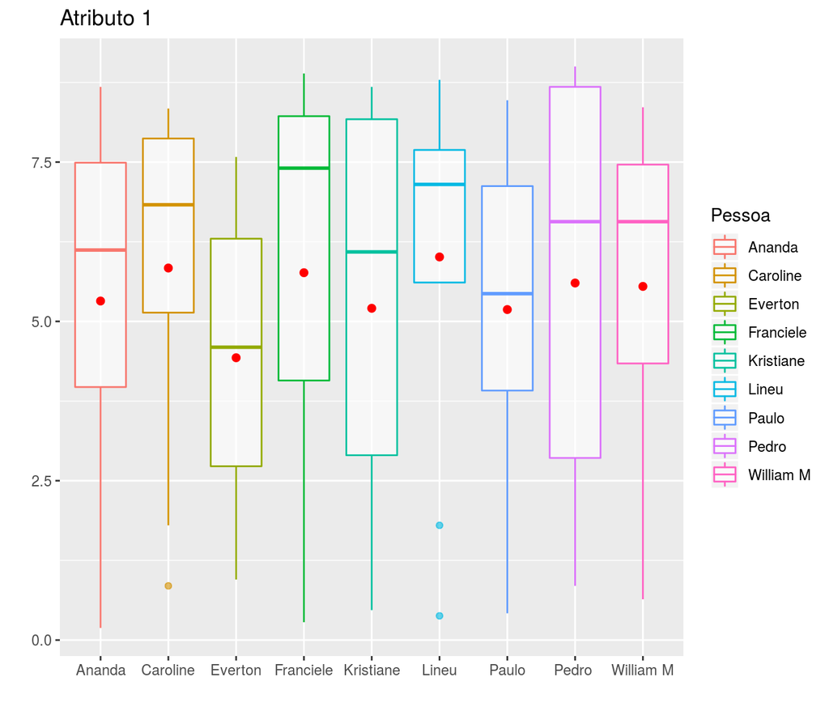

```r
# Exploratória

dados <- read.csv2('data.csv', sep = ',', dec = '.', header = T)


#-------------------------------------------------------------
library(ggplot2)
# julgador x atributo

ggplot(data = dados, mapping = aes(x=Pessoa, y=A1, color=Pessoa)) +
  geom_boxplot(alpha = 0.6)+
  stat_summary(fun.y=mean,
               geom="point",
               shape=20,
               size=3,
               color="red",
               fill="red")+
  xlab('') +
  ylab('') +
  ggtitle('Atributo 1')
```

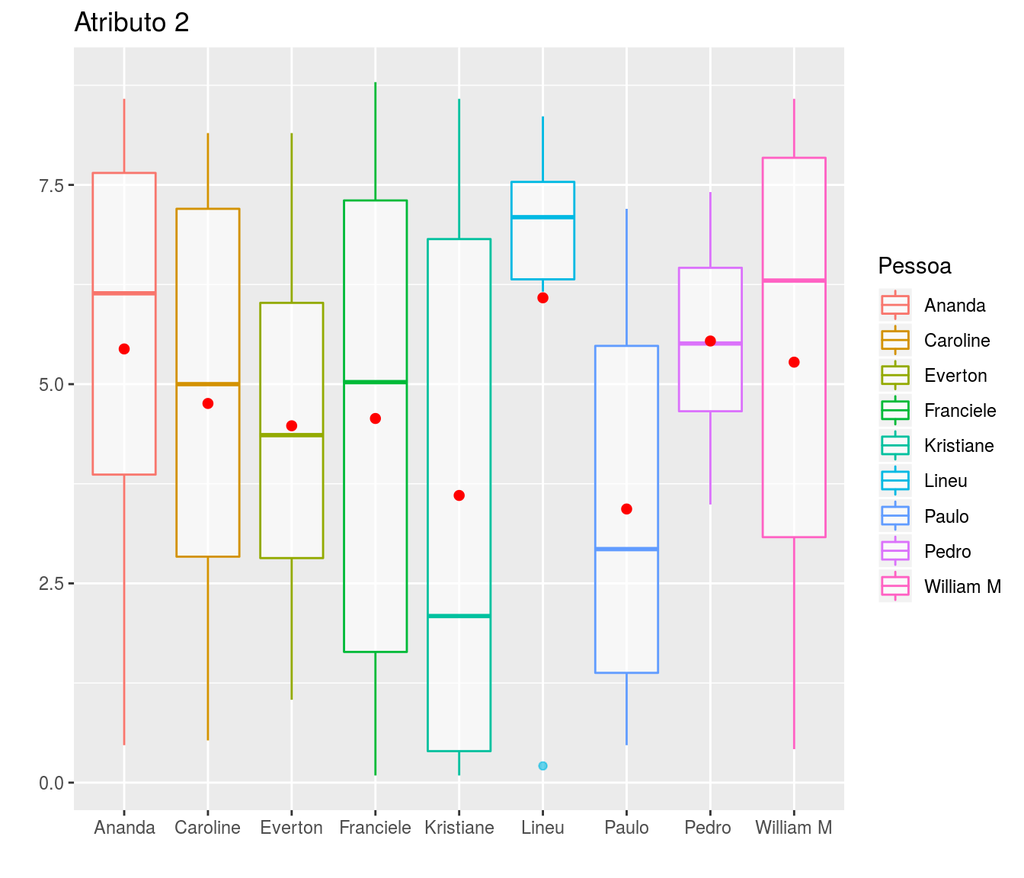

```r
ggplot(data = dados, mapping = aes(x=Pessoa, y=A2, color=Pessoa)) +
  geom_boxplot(alpha = 0.6)+
  stat_summary(fun.y=mean,
               geom="point",
               shape=20,
               size=3,
               color="red",
               fill="red")+
  xlab('') +
  ylab('') +
  ggtitle('Atributo 2')
```

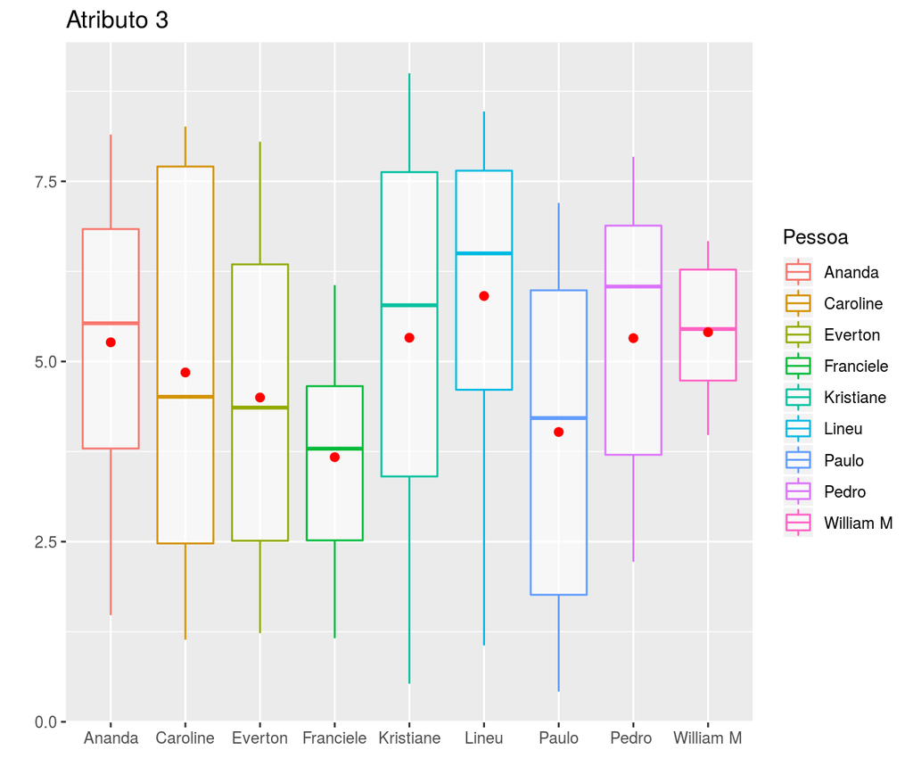

```r
ggplot(data = dados, mapping = aes(x=Pessoa, y=A3, color=Pessoa)) +
  geom_boxplot(alpha = 0.6)+
  stat_summary(fun.y=mean,
               geom="point",
               shape=20,
               size=3,
               color="red",
               fill="red")+
  xlab('') +
  ylab('') +
  ggtitle('Atributo 3')
```

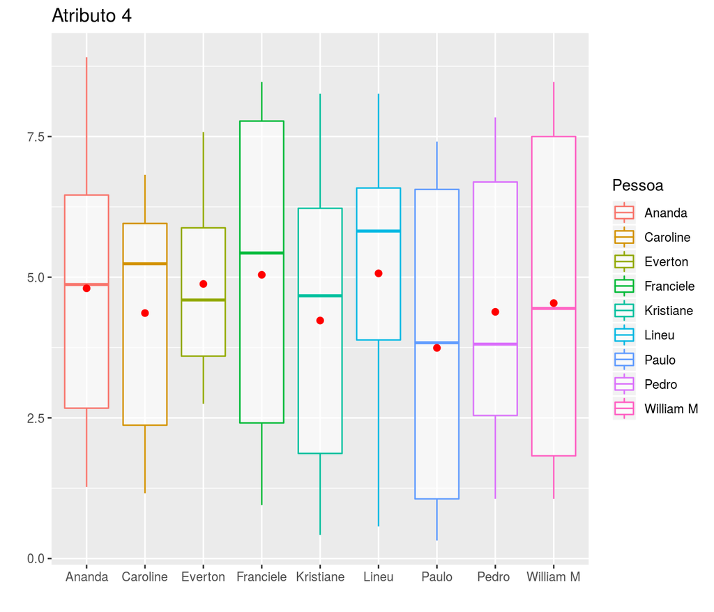

```r
ggplot(data = dados, mapping = aes(x=Pessoa, y=A4, color=Pessoa)) +
  geom_boxplot(alpha = 0.6)+
  stat_summary(fun.y=mean,
               geom="point",
               shape=20,
               size=3,
               color="red",
               fill="red")+
  xlab('') +
  ylab('') +
  ggtitle('Atributo 4')
```

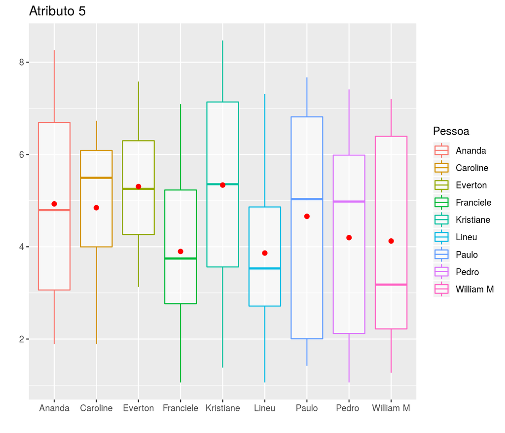

```r
ggplot(data = dados, mapping = aes(x=Pessoa, y=A5, color=Pessoa)) +
  geom_boxplot(alpha = 0.6)+
  stat_summary(fun.y=mean,
               geom="point",
               shape=20,
               size=3,
               color="red",
               fill="red")+
  xlab('') +
  ylab('') +
  ggtitle('Atributo 5')
```

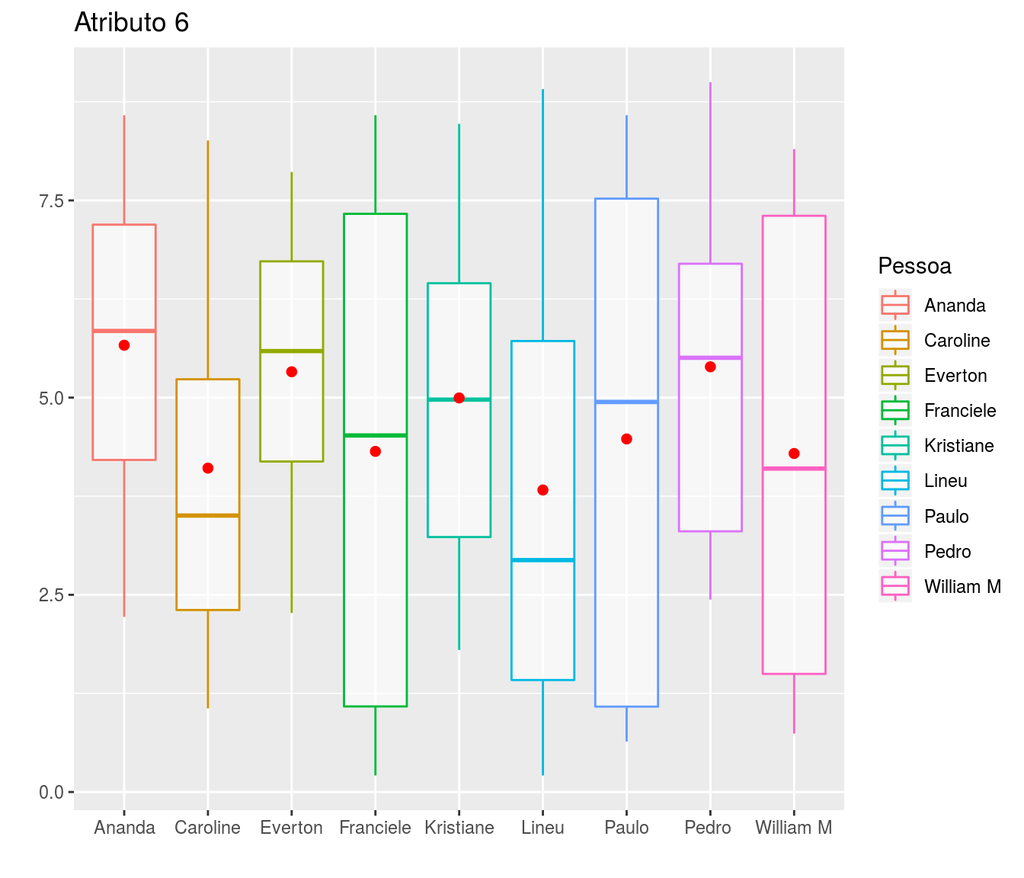

```r
ggplot(data = dados, mapping = aes(x=Pessoa, y=A6, color=Pessoa)) +
  geom_boxplot(alpha = 0.6)+
  stat_summary(fun.y=mean,
               geom="point",
               shape=20,
               size=3,
               color="red",
               fill="red")+
  xlab('') +
  ylab('') +
  ggtitle('Atributo 6')
```

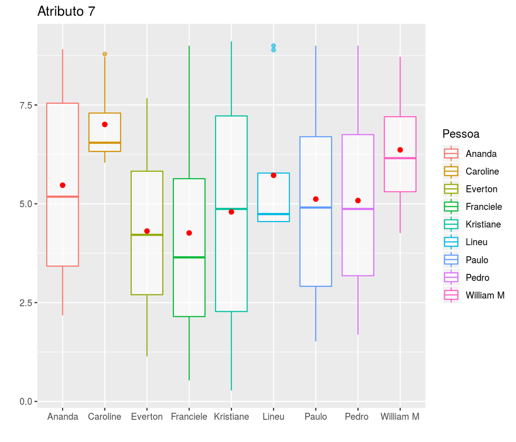

```r
ggplot(data = dados, mapping = aes(x=Pessoa, y=A7, color=Pessoa)) +
  geom_boxplot(alpha = 0.6)+
  stat_summary(fun.y=mean,
               geom="point",
               shape=20,
               size=3,
               color="red",
               fill="red")+
  xlab('') +
  ylab('') +
  ggtitle('Atributo 7')
```

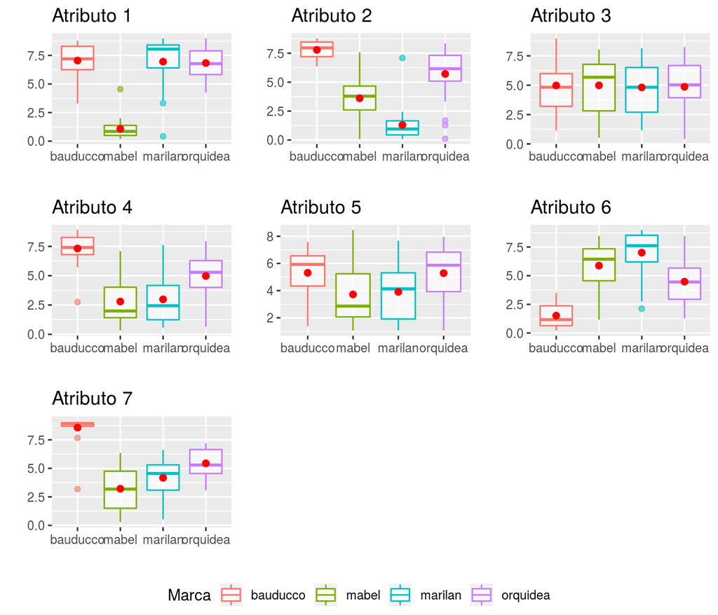

```r
#-------------------------------------------------------------

# marca x atributo

g1<-
  ggplot(data = dados, mapping = aes(x=Marca, y=A1, color=Marca)) +
  geom_boxplot(alpha = 0.6)+
  stat_summary(fun.y=mean,
               geom="point",
               shape=20,
               size=3,
               color="red",
               fill="red")+
  xlab('') +
  ylab('') +
  ggtitle('Atributo 1')

g2<-
  ggplot(data = dados, mapping = aes(x=Marca, y=A2, color=Marca)) +
  geom_boxplot(alpha = 0.6)+
  stat_summary(fun.y=mean,
               geom="point",
               shape=20,
               size=3,
               color="red",
               fill="red")+
  xlab('') +
  ylab('') +
  ggtitle('Atributo 2')

g3<-
  ggplot(data = dados, mapping = aes(x=Marca, y=A3, color=Marca)) +
  geom_boxplot(alpha = 0.6)+
  stat_summary(fun.y=mean,
               geom="point",
               shape=20,
               size=3,
               color="red",
               fill="red")+
  xlab('') +
  ylab('') +
  ggtitle('Atributo 3')

g4<-
  ggplot(data = dados, mapping = aes(x=Marca, y=A4, color=Marca)) +
  geom_boxplot(alpha = 0.6)+
  stat_summary(fun.y=mean,
               geom="point",
               shape=20,
               size=3,
               color="red",
               fill="red")+
  xlab('') +
  ylab('') +
  ggtitle('Atributo 4')

g5<-
  ggplot(data = dados, mapping = aes(x=Marca, y=A5, color=Marca)) +
  geom_boxplot(alpha = 0.6)+
  stat_summary(fun.y=mean,
               geom="point",
               shape=20,
               size=3,
               color="red",
               fill="red")+
  xlab('') +
  ylab('') +
  ggtitle('Atributo 5')

g6<-
  ggplot(data = dados, mapping = aes(x=Marca, y=A6, color=Marca)) +
  geom_boxplot(alpha = 0.6)+
  stat_summary(fun.y=mean,
               geom="point",
               shape=20,
               size=3,
               color="red",
               fill="red")+
  xlab('') +
  ylab('') +
  ggtitle('Atributo 6')

g7<-
  ggplot(data = dados, mapping = aes(x=Marca, y=A7, color=Marca)) +
  geom_boxplot(alpha = 0.6)+
  stat_summary(fun.y=mean,
               geom="point",
               shape=20,
               size=3,
               color="red",
               fill="red")+
  xlab('') +
  ylab('') +
  ggtitle('Atributo 7')

library(ggpubr)
ggarrange(g1,g2,g3,g4,
          g5,g6,g7,
          nrow = 3, ncol=3,
          common.legend = TRUE,
          legend="bottom",
          #labels = 'TÍTULO',
          font.label = list(size = 18,
                            face = "bold"))
```

## 6.3 ANOVA

Código genérico para realização da Análise de Variância por atributo e Marca:

```r
aov(Atributo ~ Avaliador, data = dados) # avaliador

aov(Atributo ~ Marca, data = dados) # marca
```

### 6.3.1 Por Atributo

Deseja-se avaliar se existe um concenso entre os avaliadores de acordo com as marcas utilizadas. Assumindo independencia entre os avaliadores:

```r
#Lendo os dados

#data <- "/home/will/Documentos/Will Meira/GitHub/Disciplinas/Optativas/CE063C - Sensometria/Experimento 05 - ADQ/Apresentação/data.csv"

dados <- read.csv('data.csv', header = TRUE, sep = ",", dec = ",")
```

#### 6.3.1.1 Atributo 1

```r
## Atributo 1
dados$A1 <- as.numeric(as.character(dados$A1))
anova1<-aov(A1 ~ Marca,data = dados)
summary(anova1)
```

```
##             Df Sum Sq Mean Sq F value Pr(>F)
## Marca        3  595.5  198.51   83.07 <2e-16 ***
## Residuals   88  210.3    2.39
## ---
## Signif. codes:  0 '***' 0.001 '**' 0.01 '*' 0.05 '.' 0.1 ' ' 1
```

#### 6.3.1.2 Atributo 2

```r
## Atributo 2
dados$A2 <- as.numeric(as.character(dados$A2))
anova2<-aov(A2 ~ Marca,data = dados)
summary(anova2)
```

```
##             Df Sum Sq Mean Sq F value Pr(>F)
## Marca        3  481.3  160.45    51.6 <2e-16 ***
## Residuals   83  258.1    3.11
## ---
## Signif. codes:  0 '***' 0.001 '**' 0.01 '*' 0.05 '.' 0.1 ' ' 1
## 5 observations deleted due to missingness
```

#### 6.3.1.3 Atributo 3

```r
## Atributo 3
dados$A3 <- as.numeric(as.character(dados$A3))
anova3<-aov(A3 ~ Marca,data = dados)
summary(anova3)
```

```
##             Df Sum Sq Mean Sq F value Pr(>F)
## Marca        3    0.5   0.178   0.033  0.992
## Residuals   87  473.6   5.444
## 1 observation deleted due to missingness
```

#### 6.3.1.4 Atributo 4

```r
## Atributo 4
dados$A4 <- as.numeric(as.character(dados$A4))
anova4<-aov(A4 ~ Marca,data = dados)
summary(anova4)
```

```
##             Df Sum Sq Mean Sq F value   Pr(>F)
## Marca        3  308.3  102.77   28.65 5.11e-13 ***
## Residuals   88  315.7    3.59
## ---
## Signif. codes:  0 '***' 0.001 '**' 0.01 '*' 0.05 '.' 0.1 ' ' 1
```

#### 6.3.1.5 Atributo 5

```r
## Atributo 5
dados$A5 <- as.numeric(as.character(dados$A5))
anova5<-aov(A5 ~ Marca,data = dados)
summary(anova5)
```

```
##             Df Sum Sq Mean Sq F value Pr(>F)
## Marca        3   49.1  16.362   3.885 0.0118 *
## Residuals   84  353.7   4.211
## ---
## Signif. codes:  0 '***' 0.001 '**' 0.01 '*' 0.05 '.' 0.1 ' ' 1
## 4 observations deleted due to missingness
```

#### 6.3.1.6 Atributo 6

```r
## Atributo 6
dados$A6 <- as.numeric(as.character(dados$A6))
anova6<-aov(A6 ~ Marca,data = dados)
summary(anova6)
```

```
##             Df Sum Sq Mean Sq F value   Pr(>F)
## Marca        3  389.1  129.70   37.44 1.09e-15 ***
## Residuals   88  304.8    3.46
## ---
## Signif. codes:  0 '***' 0.001 '**' 0.01 '*' 0.05 '.' 0.1 ' ' 1
```

#### 6.3.1.7 Atributo 7

```r
## Atributo 7
dados$A7 <- as.numeric(as.character(dados$A7))
anova7<-aov(A7 ~ Marca,data = dados)
summary(anova7)
```

```
##             Df Sum Sq Mean Sq F value Pr(>F)
## Marca        3  376.2  125.39   52.78 <2e-16 ***
## Residuals   88  209.0    2.38
## ---
## Signif. codes:  0 '***' 0.001 '**' 0.01 '*' 0.05 '.' 0.1 ' ' 1
```

### 6.3.2 Por Avaliador

Deseja-se avaliar se existe um concenso entre os avaliadores de acordo com as marcas utilizadas. Assumindo independencia entre os avaliadores:

#### 6.3.2.1 Atributo 1

```r
anova1p <- aov(A1 ~ as.factor(Pessoa), data = dados)
summary(anova1p)
```

```
##                   Df Sum Sq Mean Sq F value Pr(>F)
## as.factor(Pessoa)  8   11.1   1.393   0.145  0.997
## Residuals         83  794.7   9.575
```

#### 6.3.2.2 Atributo 2

```r
dados$A2 <- as.numeric(as.character(dados$A2))
anova2p <- aov(A2 ~ as.factor(Pessoa), data = dados)
summary(anova2p)
```

```
##                   Df Sum Sq Mean Sq F value Pr(>F)
## as.factor(Pessoa)  8   62.5   7.816   0.901   0.52
## Residuals         78  676.9   8.679
## 5 observations deleted due to missingness
```

#### 6.3.2.3 Atributo 3

```r
dados$A3 <- as.numeric(as.character(dados$A3))
anova3p <- aov(A3 ~ as.factor(Pessoa), data = dados)
summary(anova3p)
```

```
##                   Df Sum Sq Mean Sq F value Pr(>F)
## as.factor(Pessoa)  8   45.0   5.625   1.075  0.389
## Residuals         82  429.1   5.233
## 1 observation deleted due to missingness
```

#### 6.3.2.4 Atributo 4

```r
dados$A4 <- as.numeric(as.character(dados$A4))
anova4p <- aov(A4 ~ as.factor(Pessoa), data = dados)
summary(anova4p)
```

```
##                   Df Sum Sq Mean Sq F value Pr(>F)
## as.factor(Pessoa)  8   15.8   1.979    0.27  0.974
## Residuals         83  608.1   7.327
```

```r
dados$A5 <- as.numeric(as.character(dados$A5))
anova5p <- aov(A4 ~ as.factor(Pessoa), data = dados)
summary(anova5p)
```

[output not shown]

```r
dados$A6 <- as.numeric(as.character(dados$A6))
anova6p <- aov(A3 ~ as.factor(Pessoa), data = dados)
summary(anova6p)
```

[output not shown]

#### 6.3.2.7 Atributo 7

```r
dados$A7 <- as.numeric(as.character(dados$A7))
anova7p <- aov(A7 ~ as.factor(Pessoa), data = dados)
summary(anova7p)
```

```
##                   Df Sum Sq Mean Sq F value Pr(>F)
## as.factor(Pessoa)  8   59.3   7.415    1.17  0.327
## Residuals         83  525.9   6.336
```